# Communicating Data Insight on Ford GoBike(Part2/2)

## by Aluko Bamidele

## Investigation Overview

This project is focus on the importance of data visualization techniques in data analysis. This project is divided into two(2) part.

The first part, i employ the use of python libraries to wrangle and explore the ford-go-bike trup data. The wrangled and clean file is now been used to plots graphs, chart with single variables up to multiple variables.

The second part of the project is focus on presenting the insigts that i discovered in the part 1 section of the project.

## Dataset Overview

The data set explored consist of trip data for individual made in a bike shaing system in San-Francisco Bay area. The dataset consist 183412 bike trips each with duration and start and end location of each trip and other informations. I further created variable liks the days of the week, duration in hours in other to enhance out findings.

## Day and Time Service Usage

From the chat above, shows the daily distribution of service usage. The Usage of this services is**high on the weekday** and **less on the weekends.** with Thursday as the peck usage day.

The usage is also high during the peak hours of the day.

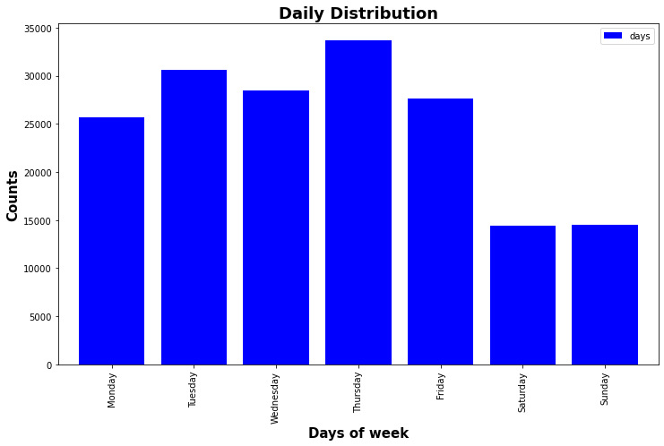

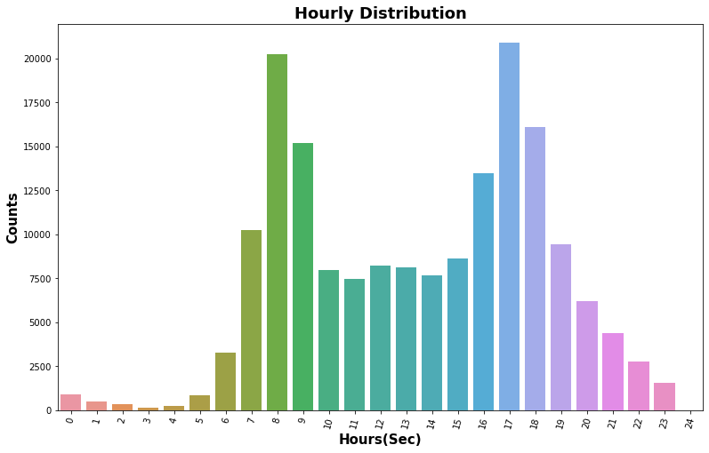

## User Type Comprison

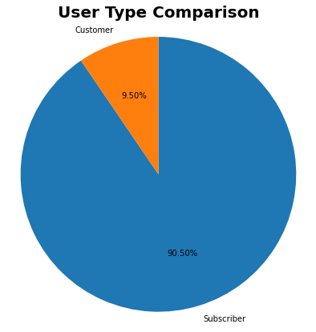

## Stations Usage

**Market st at 10th st** and **San Francisco Caltron Station 2** are on top of the chart. The **Market st at 10th st** has over **3500** trip initiating from the station while **San Francisco Caltron Station 2** has a little **less than 3500** rides initiating from the station.There is an alternating in positions between the two station. **Market st at 10th st** is on top of the list in the most used start stations and came second in the most used end station. We can agree that **San Francisco Caltron Station 2** which has over bikes ending their trip at that station show or might indicate that such station is located at one of the busiest area of the town.

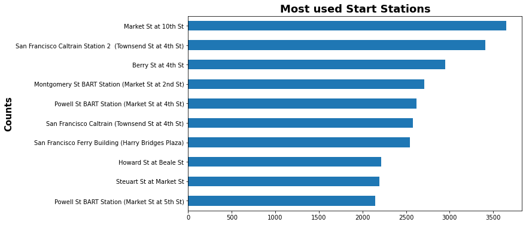

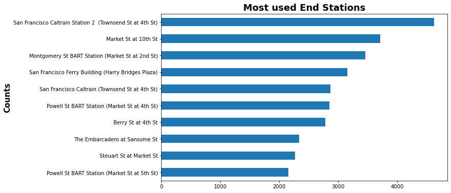

## Relationship Between Age and Duration

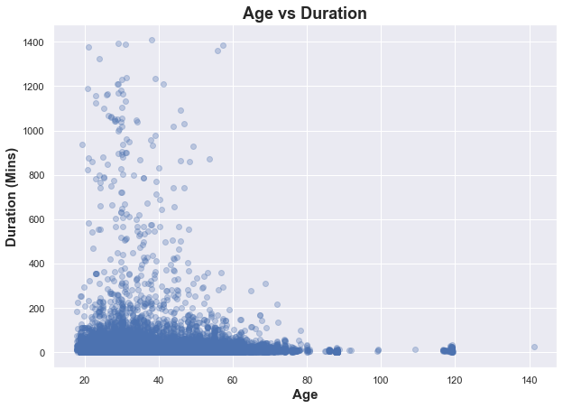

## Relationship Between User Type vs Service Usage by hour and Day

- The usage of the services by suscribers are high compare to that of the customers. The use of the services by the subscribers are high during the peak hours. THough that of the customers seems to maintian almost same level, there is also a slight increase during the peak hours also.
- **This can be said that being a suscriber to the services has great influene in the usage of the services.**

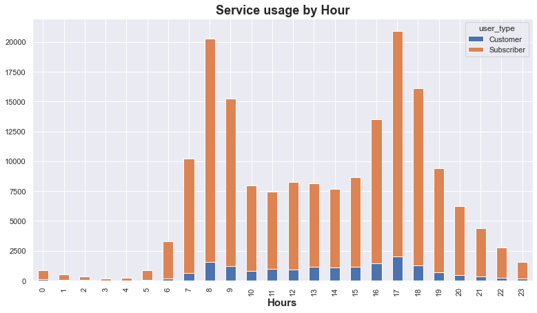

The box plot above show that despite not using the bike sharing system for all trip, the duration covered is high compare to those using it for all trip.

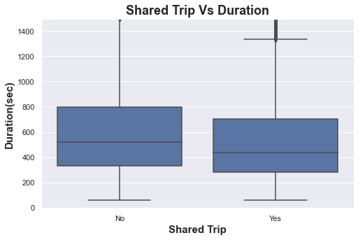

## Relationship Between Gender and Duration

- The volume of male riders are high compare to the female riders. Comparing the gender variable with the duration covered, , it show that female riders engage in longer trips that the males.
- It is also seen that most persons whose gender are not recorded as either male or female also covered longer distance. This shows the inaccuracy of the data.

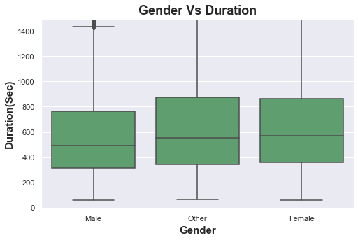

## Relationship Between Gender, Age and Duration

The two plot shows a similar trend. But is it observe that the male gender shows a slight volumn of male users that went above 40000 seconds of trip compare to the female chart. Comparing the volumn of male to female participant, it can be said that Gender does not have much effect on the usage duration rather age does.

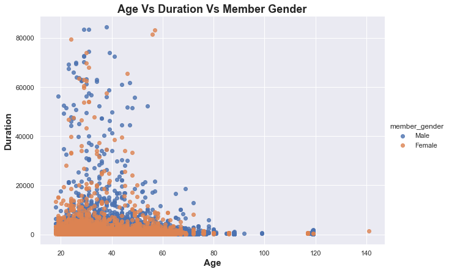

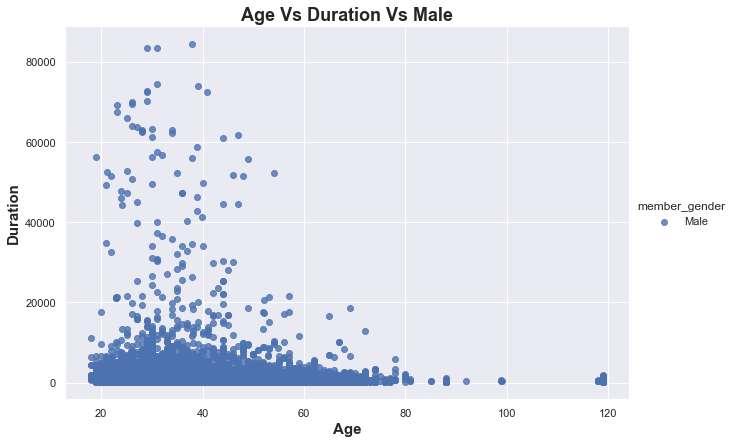

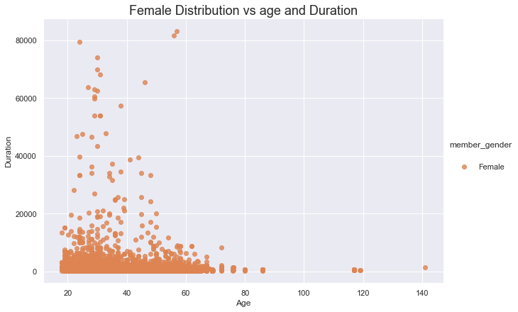

## Key Insight

- Age has a significant effect on the distance covered
- Those who do not use the bike share system for all trip still spend more time using the system.
- There are more active activities during weekdays than on weekends
- Subscribers are actively using the services that the customers